# Tema 2.1 - Visualización

## Coordenadas

Por defecto `ggplot2` usa coordenadas Cartesianas. Las coordenadas pueden modificarse con `coord_xxx()`

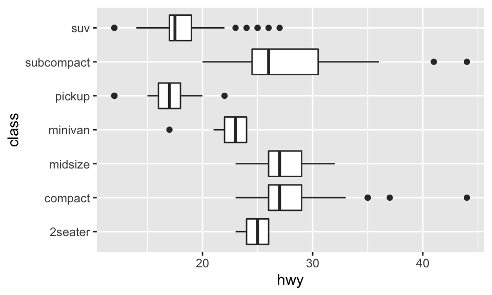

```r
ggplot(data = mpg, mapping = aes(x = class, y = hwy)) +
  geom_boxplot() +
  coord_flip() #<<
```

## Coordenadas

`coord_quickmap()` calcula el ratio correcto para mapas

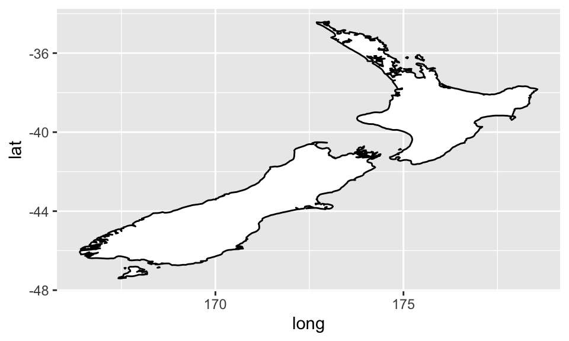

```r
library(maps)
nz <- map_data("nz")

ggplot(nz, aes(long, lat, group = group)) +
  geom_polygon(fill = "white", colour = "black")
```

## Coordenadas

`coord_quickmap()` calcula el ratio correcto para mapas

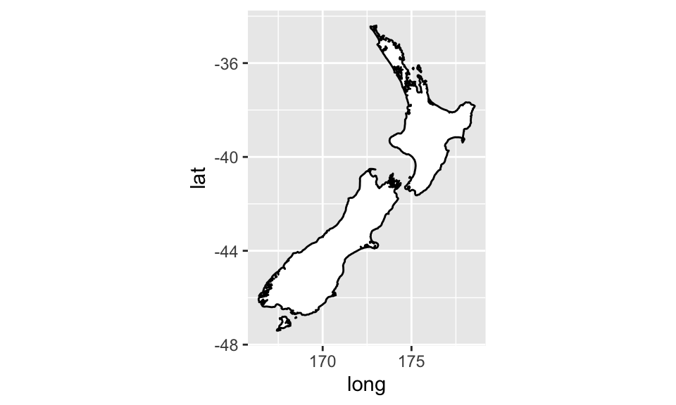

```r
ggplot(nz, aes(long, lat, group = group)) +
  geom_polygon(fill = "white", colour = "black") +
  coord_quickmap() #<<
```

## Coordenadas

`coord_polar()`

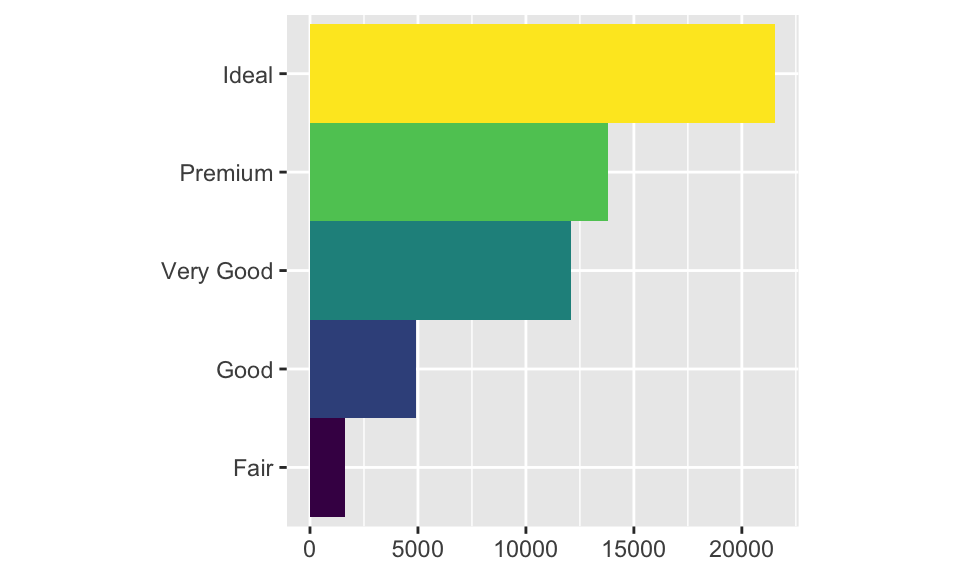

```r
bar <- ggplot(data = diamonds) +
  geom_bar(
    mapping = aes(x = cut, fill = cut),
    show.legend = FALSE,
    width = 1
  ) +
  theme(aspect.ratio = 1) +
  labs(x = NULL, y = NULL)

bar + coord_flip() #<<
```

## Coordenadas

`coord_polar()`

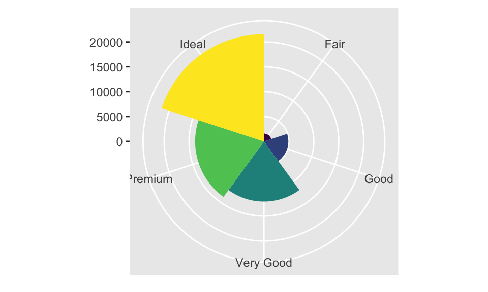

```r
bar + coord_polar()  #<<
```

## Resumen

```r
ggplot(data = <DATA>) +
  <GEOM_FUNCTION>(
     mapping = aes(<MAPPINGS>),
     stat = <STAT>,
     position = <POSITION>
  ) +
  <COORDINATE_FUNCTION> +
  <FACET_FUNCTION>
```

## Visualización: consejos

## Consejos

https://blog.csgsolutions.com/6-tips-for-creating-effective-data-visualizations

## Bibliografía

- [R for Data Science](https://r4ds.had.co.nz/), Wickham and Grolemund (2016)
- [ggplot2.tidyverse.org](http://ggplot2.tidyverse.org/)
- [Data Visualization, A practical introduction](https://socviz.co/), Healy (2018)
- [ggplot2.tidyverse.org](https://ggplot2.tidyverse.org/)
- `ggplot2` [cheat sheet](https://diegokoz.github.io/intro_ds/fuentes/ggplot2-cheatsheet-2.1-Spanish.pdf)
- [Top 50 `ggplot2` visualizations](http://r-statistics.co/Top50-Ggplot2-Visualizations-MasterList-R-Code.html)
- [How the BBC uses `ggplot2`](https://medium.com/bbc-visual-and-data-journalism/how-the-bbc-visual-and-data-journalism-team-works-with-graphics-in-r-ed0b35693535)
- [ggplot2: Elegant Graphics for Data Analysis](https://ggplot2-book.org/)